# MSGL README

2019-05-07

## Multinomial sparse group lasso

Multiclass classification with feature and parameter selection using sparse group lasso for the multinomial model. Suitable for high dimensional problems.

This is the R package msgl version **2.3.9**.

### R-package Overview

This package implements procedures for working with multinomial logistic regression models using sparse group lasso. This includes procedures for fitting and cross validating sparse models in a high dimensional setup. See the Getting started with msgl (predict primary cancer site based on microRNA measurements) for an example of a workflow consisting of 1) model selection and assessment using cross validation, 2) estimation of a final model and 3) using the selected model for carrying out predictions on new data.

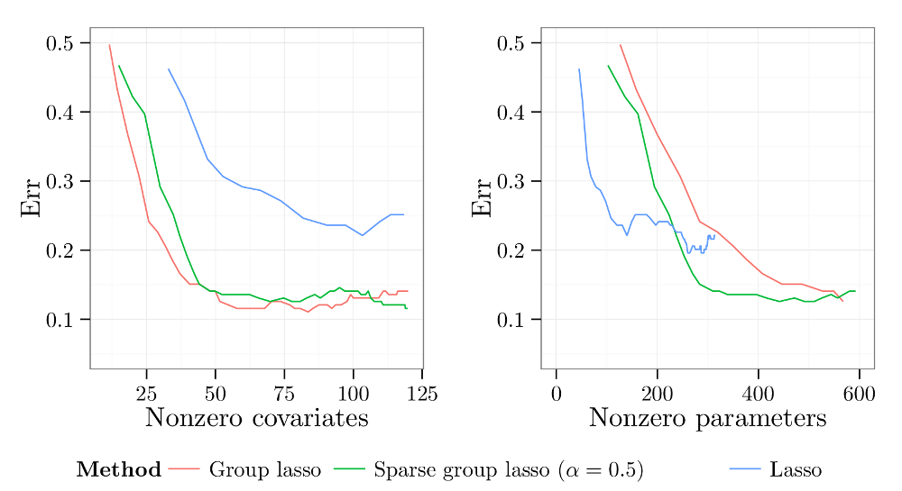

alt tag

> Classification of cancer site. Error estimated by 10-fold cross validation on a data set consisting of microRNA expression measurements of laser dissected primary cancers.

**Package highlights:**

- Feature and parameter selection
- Fast coordinate gradient descent algorithm
- Suitable for high dimensional multiclass classification
- Support for lasso, group lasso and sparse group lasso
- Supports custom grouping of features
- Supports sample weighting
- Supports individual weighting of the group and parameter penalties

The penalized maximum likelihood estimator for multinomial logistic regression is computed using a coordinate gradient descent algorithm via the sglOptim optimizer. Use of parallel computing for cross validation and subsampling is supported through the foreach and doParallel packages.

### Installation

Install the released version from CRAN:

```r
install.packages("msgl")
```

Install the version from GitHub:

```r
# install.packages("devtools")
devtools::install_github("nielsrhansen/sglOptim", build_vignettes = TRUE)
devtools::install_github("nielsrhansen/msgl", build_vignettes = TRUE)
```

If you don’t want to build the vignettes when installing, just remove the `build_vignettes = TRUE` argument.

### Minimal Example

```r
library(msgl)
# Load some data
data(PrimaryCancers)

# Setup 2 parallel units
cl <- makeCluster(2)
registerDoParallel(cl)

# Do 10-fold cross validation on 100 models with increasing complexity, using the 2 parallel units
fit.cv <- msgl::cv(
  x = x,
  classes = classes,
  alpha = 0.5,
  lambda = 0.5,
  use_parallel = TRUE
)
```

```
## Running msgl 10 fold cross validation (dense design matrix)
##
##  Samples:  Features:  Classes:  Groups:  Parameters:
##        165        372         9      372       3.348k
```

```r
stopCluster(cl)

# Print information about models
# and cross validation errors
fit.cv
```

```
##
## Call:
## msgl::cv(x = x, classes = classes, alpha = 0.5, lambda = 0.5,
##     use_parallel = TRUE)
##
## Models:
##
##  Index:  Lambda:  Features:  Parameters:  Error:
##        1     1.00        1.5         11.4    0.96
##       20     0.88        4.5         28.2    0.76
##       40     0.76          8         47.8    0.66
##       60     0.66       11.7         66.9    0.52
##       80     0.58       15.6         87.7    0.42
##      100     0.50       21.2        115.1    0.38
##
## Best model:
##
##  Index:  Lambda:  Features:  Parameters:  Error:
##       94     0.52       19.2          106    0.37
```

### Documentation

- R package documentation
- Getting started with msgl (Predict primary cancer site based on microRNA measurements)
- [Sparse group lasso and high dimensional multinomial classification](http://dx.doi.org/10.1016/j.csda.2013.06.004) paper in Computational Statistics & Data Analysis

### Author

Martin Vincent wrote the package. Niels Richard Hansen is the current maintainer.

### License

GPL (>=2)